# Predicting Coronary Artery Disease with Neural Networks using H2O

David Noonan

Coronary artery disease (CAD) is a group of diseases which are the most common type of heart disease. It is estimated to kill 8.9 million people each year worldwide. An important source of data on CAD comes from the National Health and Nutrition Examination Survey (NHANES). It is a survey of physical examinations, laboratory exams, and interviews from a nationwide representative sample in the United States collected by the National Center for Health Statistics. Using this data, I aim to predict whether a person has coronary heart disease based on laboratory test data using artificial neural networks with the h2o package in R. The goal of the model is classification: whether the disease is present or not.

# Step 1 Collecting the Data

The data were collected from the NHANES website’s 2013-2014 survey. It is formatted in SAS xport files (.XPT). These were imported into R using the **sasxport.get** function from the **Hmisc** package in R.

# Step 2 Exploring and Preparing the data

**Variable subset selection**

After import, I merged the data frames. The result was a data frame of 10175 observations from 719 variables. I needed to decide which variables to use. Arbitrarily, I chose to remove variables with greater than 1000 missing observations. This was a very large proportion of the data. The result was a data frame of 5769 observations from 30 variables.

**Handling NAs**

Next, I needed to address the missing values in the data. Below is a map of the missing dataor the first 100 observatons:

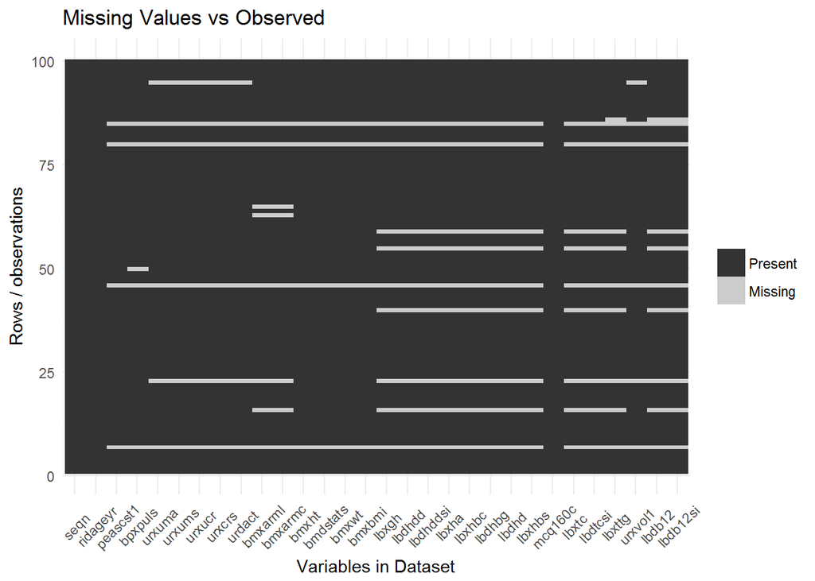

From this plot, we see that the missing data is correlated. If an observation is missing in one laboratory test, it’s likely missing in all or many of the others. I removed the observations that had this pattern. The result was 5046 observations from 30 variables. I also removed observations with missing values when they made up a small fraction of the dataset (less than .01%).

Another change to the data was to recode the outcome variable. Its name is “mcq160c”, which is an observation based on an interview question: “have you been told [by a medical professional] that you have coronary [artery] disease?”. The answer is “1” for positive, and “2” for negative. I changed “1” to “positive” and “2” to “negative.” Finally, I renamed the variable “CAD”, for coronary artery disease. Below is the distriubtion of that variable:

```
##
##    1    2
##  191 4827
```

The number of diseased patients is slightly less than 4% of the data. Next we look at the mean age for each outcome:

```
## # A tibble: 2 × 3
##        CAD count mean.age
##     <fctr> <int>    <dbl>
## 1 positive   191 67.49738
## 2 negative  4827 47.80029
```

It is interesting to note that age is strongly associated with CAD here. Below is a comparison of the age distributions for each outcome:

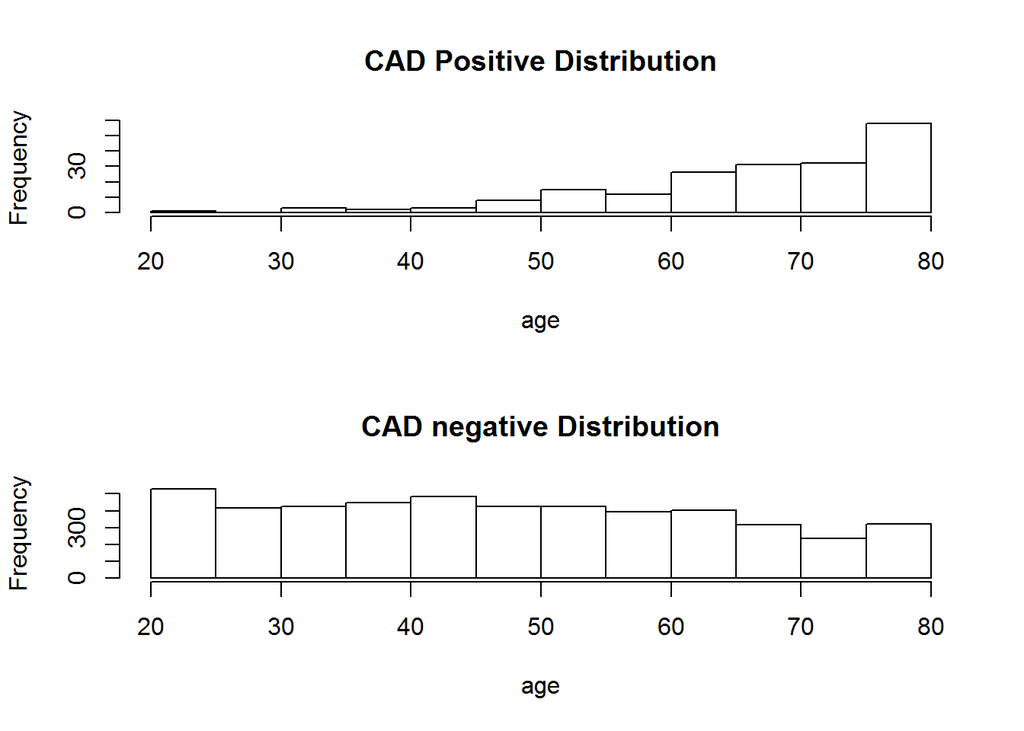

We see that CAD positive observations tend to occur with greater ages. However, there are some CAD cases in the 20s and 30s.